# MLBA Lab 1 - Introduction to Quarto

An introduction to Quarto

Ilia Azizi

02.03.2026

## Motivation

- Learning about Quarto
  - What are its output formats? Reports (PDF, HTML, Docx), Presentations (PPT, KEY, HTML) & websites (HTML).
- Learning how to interact with Quarto
  - How can it be used? It can be used with many integrated development environments (IDEs) such as Rstudio, Jupyter Notebook & VSCode.
- Using what we have seen in class with Quarto
  - Reason(s) to use? Good application for ML course & reporting in general. It particularly benefits interactive reporting, especially when multiple programming languages are involved.

## What is `Quarto`?

- Quarto® is an open-source scientific and technical publishing system built on Pandoc.
- Pandoc is a versatile tool for converting documents from one format to another. It allows you to convert a document written in one markup language to another markup language, such as converting a Markdown document to HTML or LaTeX.
- Think of Quarto as R-markdown on steroids.

[figure not shown]

## Formats

- Websites
- Books
- Blogs
- Journals

[figure not shown]

nbdev.fast.ai

[figure not shown]

Python for Data Analysis, 3E by Wes McKinney

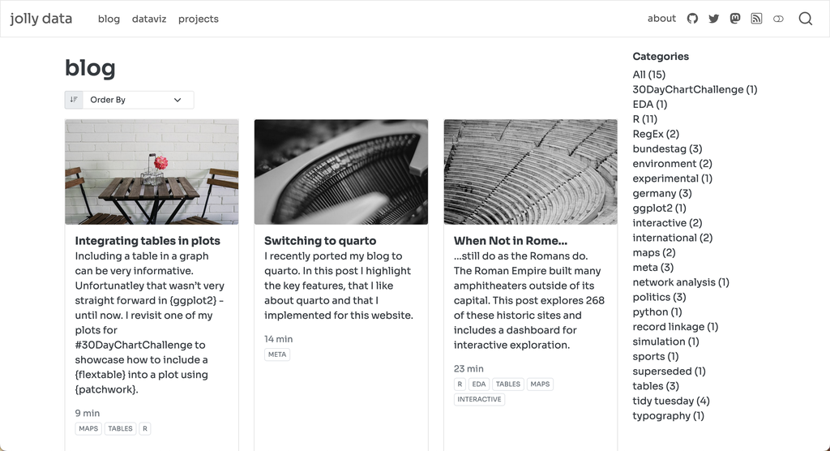

https://jollydata.blog/

[figure not shown]

Journal of Statistical Software (JSS)

## Compatibility

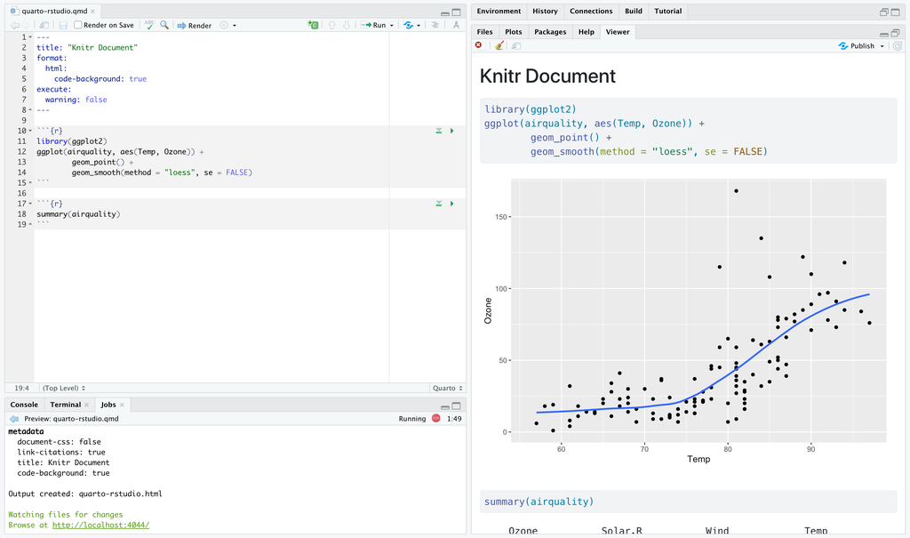

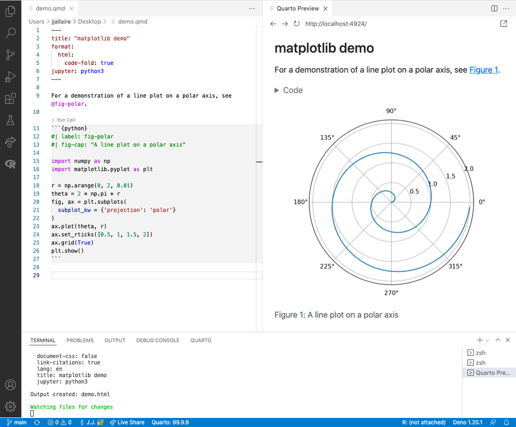

[figure not shown]

..and many other editors. For more info, please see https://quarto.org/docs/get-started/

# Rstudio Demo

## Presentations: Pretty Code

- Over 20 syntax highlighting themes available
- Default theme optimized for accessibility

```r
# Define a server for the Shiny app
function(input, output) {

  # Fill in the spot we created for a plot
  output$phonePlot <- renderPlot({
    # Render a barplot
  })
}
```

## Presentations: Code Animations

- Over 20 syntax highlighting themes available
- Default theme optimized for accessibility

```r
# Define a server for the Shiny app
function(input, output) {

  # Fill in the spot we created for a plot
  output$phonePlot <- renderPlot({
    # Render a barplot
    barplot(WorldPhones[,input$region]*1000,
            main=input$region,
            ylab="Number of Telephones",
            xlab="Year")
  })
}
```

## Presentations: Line Highlighting

- Highlight specific lines for emphasis
- Incrementally highlight additional lines

```python
import numpy as np
import matplotlib.pyplot as plt
r = np.arange(0, 2, 0.01)
theta = 2 * np.pi * r
fig, ax = plt.subplots(subplot_kw={'projection': 'polar'})
ax.plot(theta, r)
ax.set_rticks([0.5, 1, 1.5, 2])
ax.grid(True)
plt.show()
```

## Presentations: Executable Code

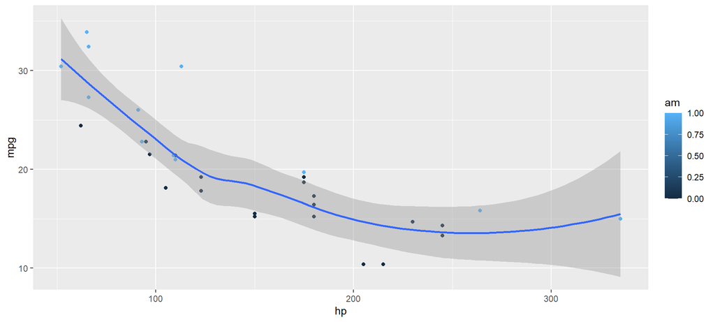

```r
library(ggplot2)
ggplot(mtcars, aes(hp, mpg, color = am)) +
    geom_point() + geom_smooth(formula = y ~
    x, method = "loess")
```

## Presentations: Auto-Animate

Automatically animate matching elements across slides with Auto-Animate.

## Presentations: Auto-Animate

Automatically animate matching elements across slides with Auto-Animate.

# Thank You for your attention!

Questions?

## References & Credits

- [Quarto official website & documentation](https://quarto.org)
- Slides taken from `Isabella Velásquez` from Posit (Rstudio) on [this link of `Intro to Quarto`](https://ivelasq.quarto.pub/intro-to-quarto/#/section). For the source code, please see [here](https://github.com/ivelasq/2022-10-27_intro-to-quarto/blob/main/index.qmd).
- Slides taken from the official Posit (Rstudio) website for introducing Quarto.
- Another nice resource is from Tom Mock (Posit/Rstudio), given as [webinar in 2022](https://jthomasmock.github.io/quarto-2hr-webinar). Notably, my set of slides was inspired by his [introduction slides](https://jthomasmock.github.io/quarto-2hr-webinar/materials/01-intro-quarto.html#/TitleSlide). For the entire deck of slides and source code visit this `qmd` file on [his github](https://github.com/rstudio-conf-2022/get-started-quarto/blob/main/materials/01-intro-quarto.qmd).
- Huge list of resources for Quarto with many examples from `mcanouil/awesome-quarto` found [here](https://github.com/mcanouil/awesome-quarto).